# ເສດຖະສາດມະຫາພາກ

# 1. ເສດຖະສາດມະຫາພາກ ແມ່ນຫຍັງ?

## 1.1 ເສດຖະກິດ

ໃນທາງປະຕິບັດ ເສດຖະກິດ ແມ່ນ ການຜະລິດ, ການບໍລິການ ແລະ ການຈັດການທີ່ກ່ຽວຂ້ອງ

ນິຍາມ ຂອງ ຄຳວ່າເສດຖະກິດ ໃນແຕ່ລະພາສາ:

- ພາສາອັງກິດ economy ມາຈາກຄຳວ່າ oikonomia ໃນພາສາເກຣັກ ໝາຍຄວາມວ່າ ການບໍລິຫານບ້ານ
- ພາສາຍີ່ປຸ່ນ 経済 ຫຍໍ້ມາຈາກຄຳວ່າ 経国済民 ໃນພາສາຈີນບູຮານ ແປວ່າ ການບໍລິຫານປະທດ ເພື່ອກອບກູ້ປະຊາຊົນ. ນີ້ແມ່ນຕົວຢ່າງໜຶ່ງ ຂອງ ການທີ່ປະເທດຍີ່ປຸ່ນ ນຳໃຊ້ໂຕໜັງສືຈີນບູຮານ ເພື່ອແປຄວາມໝາຍຂອງຄຳສັບເຕັກນິກ ຈາກພາສາເອີຣົບຕາເວັນຕົກ ເປັນພາສາຍີ່ປຸ່ນ ໃນໄລຍະເລີ່ມຕົ້ນ ການຫັນເປັນທັນສະໄໝ
- ພາສາລາວ ເສດຖະກິດ ມາຈາກຄຳວ່າ សេដ្ឋកិច្ច ໃນພາສາກຳປູເຈຍ ແປວ່າ ການເຮັດໃຫ້ມີຫຼາຍ ໃຫ້ອຸດົມສົມບູນ

## 1.2 ເສດຖະສາດ

ແມ່ນ ການສຶກສາກ່ຽວກັບ ເສດຖະກິດ ແບບເປັນຫຼາຍສາຂາເຊັ່ນ:

- ເສດຖະສາດມະຫາພາກບ້ານ (macroeconomics)
- ເສດຖະສາດຈຸນລະພາກ (microeconomics)
- ເສດຖະສາດພັດທະນາ (development economics)
- ປະຫວັດສາດເສດຖະກິດ (economic history)
- ເສດຖະສາດສາກົນ (international economics)
- ເສດຖະສາດສາທາລະນະ (public economics)
- ເສດຖະສາດແຮງງານ (labor economics)
- ທິດສະດີເກມ (game theory)
- ເສດຖະສາດພຶດຕິກຳ (behavioral economics)

ແລະອື່ນໆ

## 1.3 ເສດຖະສາດມະຫາພາກ

ສຶກສາກ່ຽວກັບ ເສດຖະກິດ ຂອງ ຂອບເຂດການປົກຄອງໃດໜຶ່ງ ເຊັ່ນ ປະເທດ, ແຂວງ, ເມືອງ, ຕາແສງ, ບ້ານ, …

- ຂອບເຂດການສຶກສາ ຂອງ ເສດຖະກິດມະຫາພາກ ແລະ ເສດຖະກິດຈຸນລະພາກ

[figure not shown]

## 1.4 ຮຽນເສດຖະສາດມະຫາພາກ ມີປະໂຫຍດຫຍັງ?

ຄວາມຮູ້ດ້ານເສດຖະສາດມະຫາພາກ ມີ ປະໂຫຍດຕ່າງກັນຕໍ່ແຕ່ລະສາຂາອາຊີບ ເຊັ່ນ:

- ລັດຖະກອນ: ຈະບໍລິຫານແນວໃດໃຫ້ບ້ານເມືອງພັດທະນາ
- ນັກທຸລະກິດ: ສົ່ງເສີມຄວາມເຂົ້າໃຈຕະຫຼາດ (ຂອງ ບ້ານ, ເມືອງ, ແຂວງ, ປະເທດ) ທີ່ຕົນເອງ ສົນໃຈຢາກດຳເນີນທຸລະກິດ
- ປະຊາຊົນ: ຊິບໍລິຫານເສດຖະກິດຄອບຄົວແນວໃດ

# 2. ແຜນວາດການໝຸນວຽນ ໃນ ເສດຖະກິດມະຫາພາກ

[figure not shown]

# 3. ບັນດາຄວາມຄິດຫຼັກ ໃນ ເສດຖະກິດມະຫາພາກ

## 3.1 ຜະລິດຕະພັນ, ສິນຄ້າ ແລະ ການບໍລິການ

- ຜະລິດຕະພັນ:ສີ່ງຜະລິດ
- ສິນຄ້າ: ຜະລິດຕະພັນ ເພື່ອຂາຍ (ແລກປ່ຽນ)
- ບໍລິການ: ສິນຄ້າທີ່ບໍ່ມີຕົວຕົນ ຫຼື ການຊ່ອຍຜູ້ອື່ນເຮັດອັນໃດອັນໜຶ່ງ

ຕົວຢ່າງ ສິນຄ້າ ແລະ ການບໍລິການ

[figure not shown]

### ປະເພດສິນຄ້າ

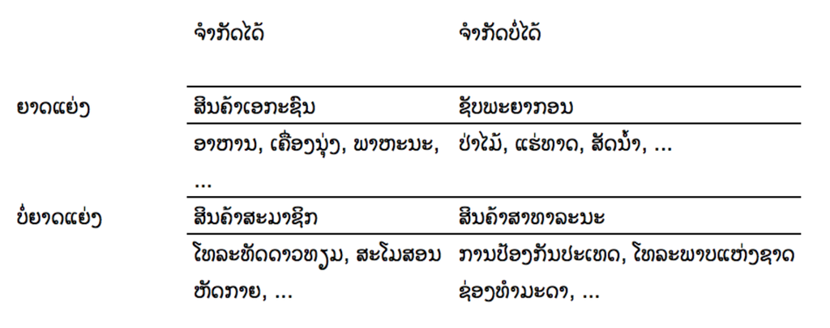

### ຕົວຢ່າງການວັດແທກເສດຖະກິດມະຫາພາກ (ຂໍ້ມູນສູນສະຖິຕິແຫ່ງຊາດ)

- ເນື້ອທີ່ປູກເຂົ້ານາປີລາຍແຂວງ

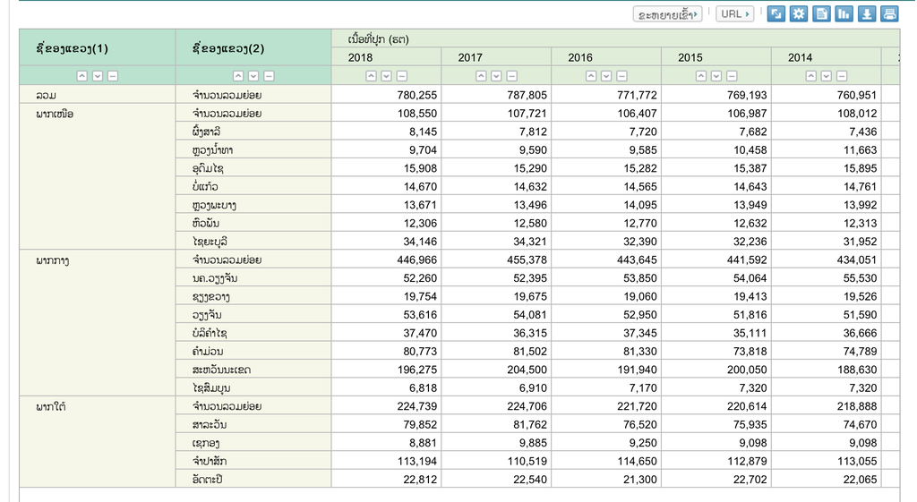

- ເນື້ອທີ່ປູກເຂົ້ານາແຊງລາຍແຂວງ

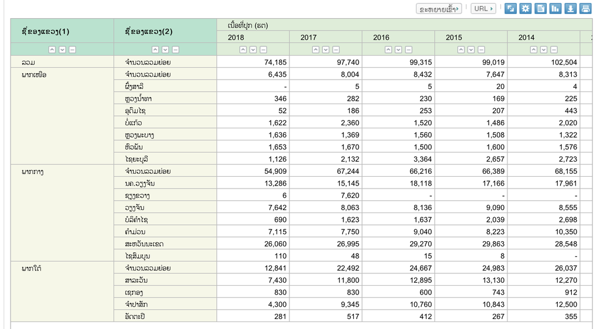

- ເນື້ອທີ່ປູກເຂົ້າໄຮ່ລາຍແຂວງ

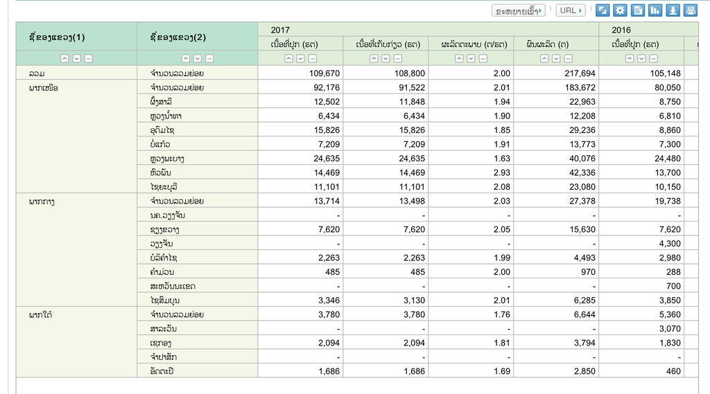

- ການປູກສາລີລາຍແຂວງ

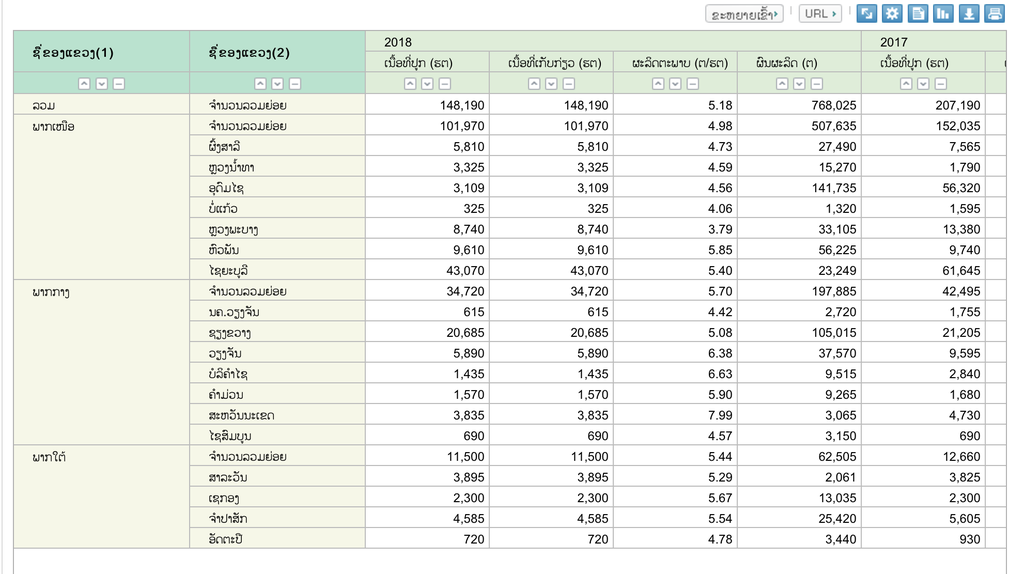

- ການປູກກາເຟລາຍແຂວງ

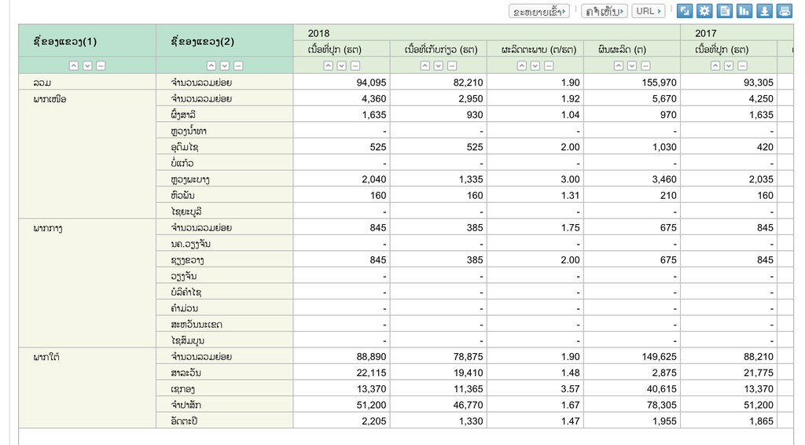

- ປະຊາກອນລາຍແຂວງ

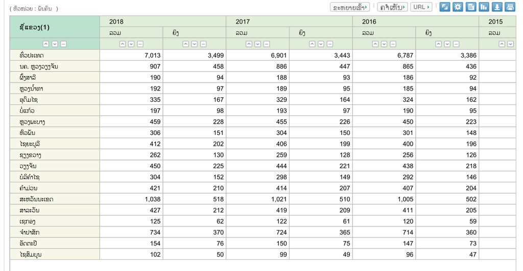

## 3.2 ຄວາມຂາດແຄນ, ການເລືອກເຟັ້ນ ແລະ ຄ່າໂອກາດ

## 3.3 ຄວາມຕ້ອງການ ແລະ ການສະໜອງ

## 3.5 ເງິນ ແລະ ເງິນເຟີ້

## 3.7 ການຜະລິດ, ປັດໃຈການຜະລິດ ແລະ ມູນຄ່າເພີ່ມ

## 3.6 ການຄ້າ ແລະ ການລົງທຶນລະຫວ່າງປະເທດ